# IS 4487 Assignment 6: Data Cleaning with Airbnb Listings

In this assignment, you will:

- Load a raw Airbnb listings dataset
- Identify and resolve missing or inconsistent data
- Decide what data to drop, keep, or clean
- Save a clean dataset to use in Assignment 7

## Why This Matters

Data cleaning is one of the most important steps in any analysis — but it's often the least visible. Airbnb hosts, managers, and policy teams rely on clean data to make decisions. This assignment gives you experience cleaning raw data and justifying your choices so others can understand your process.

## Dataset Description

The dataset you'll be using is a **detailed Airbnb listing file**, available from [Inside Airbnb](https://insideairbnb.com/get-the-data/).

Each row represents one property listing. The columns include:

- **Host attributes** (e.g., host ID, host name, host response time)
- **Listing details** (e.g., price, room type, minimum nights, availability)
- **Location data** (e.g., neighborhood, latitude/longitude)
- **Property characteristics** (e.g., number of bedrooms, amenities, accommodates)
- **Calendar/booking variables** (e.g., last review date, number of reviews)

📌 The schema is consistent across cities, so you can expect similar columns regardless of the location you choose.

## 1. Choose a City & Upload Your Dataset

📥 Follow these steps:

1. Go to: https://insideairbnb.com/get-the-data/
2. Choose a city you’re interested in.
3. Download the file named: **`listings.csv.gz`** under that city.
4. In your notebook:
   - Open the left sidebar
   - Click the folder icon 📁
   - Click the upload icon ⬆️ and choose your `listings.csv.gz` file
5. Use the file path `/content/listings.csv.gz` when loading your data.
6. Import standard libraries (`pandas`, `numpy`, `seaborn`, `matplotlib`)

```python
# Import necessary libraries 🔧
import pandas as pd
import numpy as np
import seaborn as sns
import matplotlib.pyplot as plt
```

```python
# Load your uploaded file (path "/content/listings.csv.gz") 🔧
#the listings.csv is listings from Austin, TX
df = pd.read_csv("/content/listings.csv.gz")
display(df.head())
```

|  | id | listing_url | scrape_id | last_scraped | source | name | description | neighborhood_overview | picture_url | host_id | ... | review_scores_communication | review_scores_location | review_scores_value | license | instant_bookable | calculated_host_listings_count | calculated_host_listings_count_entire_homes | calculated_host_listings_count_private_rooms | calculated_host_listings_count_shared_rooms | reviews_per_month |
| --- | --- | --- | --- | --- | --- | --- | --- | --- | --- | --- | --- | --- | --- | --- | --- | --- | --- | --- | --- | --- | --- |
| 0 | 5456 | https://www.airbnb.com/rooms/5456 | 20250613040113 | 2025-06-13 | city scrape | Walk to 6th, Rainey St and Convention Ctr | Great central location for walking to Convent... | My neighborhood is ideally located if you want... | https://a0.muscache.com/pictures/14084884/b5a3... | 8028 | ... | 4.82 | 4.73 | 4.79 | NaN | f | 1 | 1 | 0 | 0 | 3.59 |
| 1 | 5769 | https://www.airbnb.com/rooms/5769 | 20250613040113 | 2025-06-13 | city scrape | NW Austin Room | NaN | Quiet neighborhood with lots of trees and good... | https://a0.muscache.com/pictures/23822033/ac94... | 8186 | ... | 4.94 | 4.77 | 4.92 | NaN | f | 1 | 0 | 1 | 0 | 1.65 |
| 2 | 6413 | https://www.airbnb.com/rooms/6413 | 20250613040113 | 2025-06-14 | previous scrape | Gem of a Studio near Downtown | Great studio apartment, perfect a single perso... | Travis Heights is one of the oldest neighborho... | https://a0.muscache.com/pictures/hosting/Hosti... | 13879 | ... | 4.98 | 4.87 | 4.93 | NaN | f | 1 | 1 | 0 | 0 | 0.65 |
| 3 | 6448 | https://www.airbnb.com/rooms/6448 | 20250613040113 | 2025-06-13 | city scrape | Secluded Studio @ Zilker - King Bed, Bright & ... | Clean, private space with everything you need ... | The neighborhood is fun and funky (but quiet)!... | https://a0.muscache.com/pictures/airflow/Hosti... | 14156 | ... | 4.98 | 4.97 | 4.88 | NaN | t | 1 | 1 | 0 | 0 | 2.02 |
| 4 | 8502 | https://www.airbnb.com/rooms/8502 | 20250613040113 | 2025-06-13 | city scrape | Woodland Studio Lodging | Studio rental on lower level of home located i... | NaN | https://a0.muscache.com/pictures/miso/Hosting-... | 25298 | ... | 4.88 | 4.69 | 4.63 | NaN | f | 1 | 1 | 0 | 0 | 0.29 |

5 rows × 79 columns

```python
# I used df.info to see what kind of data types I'm working with
df.info()
```

```
<class 'pandas.core.frame.DataFrame'>
RangeIndex: 15187 entries, 0 to 15186
Data columns (total 79 columns):
 #   Column                                        Non-Null Count  Dtype
---  ------                                        --------------  -----
 0   id                                            15187 non-null  int64
 1   listing_url                                   15187 non-null  object
 2   scrape_id                                     15187 non-null  int64
 3   last_scraped                                  15187 non-null  object
 4   source                                        15187 non-null  object
 5   name                                          15187 non-null  object
 6   description                                   14840 non-null  object
 7   neighborhood_overview                         7914 non-null   object
 8   picture_url                                   15186 non-null  object
 9   host_id                                       15187 non-null  int64
```

[output cut: 71 more lines]

## 2. Explore Missing Values

Business framing:

Stakeholders don’t like surprises in the data. Missing values can break dashboards, confuse pricing models, or create blind spots for host managers.

Explore how complete your dataset is:

- Count the null values of each column
- Create visuals (e.g. heatmaps, boxplots, bar charts, etc) to help show what columns are missing values
- Keep in mind which column(s) are missing too much data, you will delete these in the next step

### In your markdown:

1. What are the top 3 columns with the most missing values?
2. Which ones are likely to create business issues?
3. Which could be safely ignored or dropped?

```python
# amnt of missing values by most missing values/ column to least missing values
missing_values = df.isnull().sum().sort_values(ascending=False)
display(missing_values)
```

|  | 0 |
| --- | --- |
| license | 15187 |
| calendar_updated | 15187 |
| neighbourhood_group_cleansed | 15187 |
| neighbourhood | 7273 |
| neighborhood_overview | 7273 |
| ... | ... |
| instant_bookable | 0 |
| calculated_host_listings_count | 0 |
| calculated_host_listings_count_entire_homes | 0 |
| calculated_host_listings_count_private_rooms | 0 |
| calculated_host_listings_count_shared_rooms | 0 |

79 rows × 1 columns

**dtype:** int64

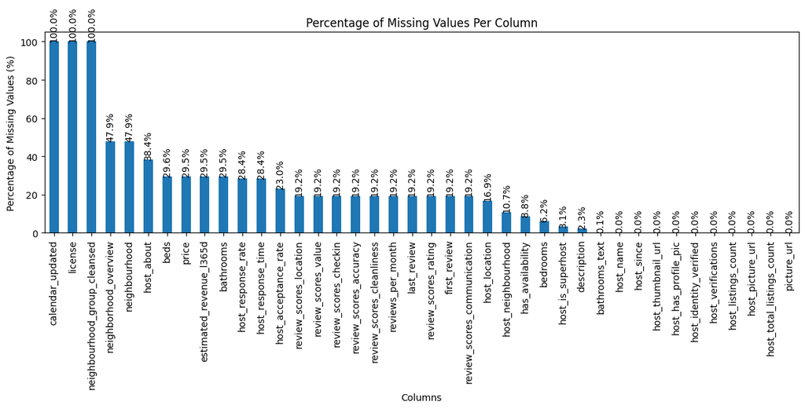

```python
# Calculate the percentage of missing values
missing_percentages = (df.isnull().sum() / len(df)) * 100

# Filter out columns with no missing values and sort
missing_percentages = missing_percentages[missing_percentages > 0].sort_values(ascending=False)

# Plotting
plt.figure(figsize=(12, 6))
ax = missing_percentages.plot(kind='bar')
plt.title('Percentage of Missing Values Per Column')
plt.ylabel('Percentage of Missing Values (%)')
plt.xlabel('Columns')
plt.xticks(rotation=90)
plt.tight_layout()

# Add percentage labels on top of bars
for i, v in enumerate(missing_percentages):
    ax.text(i, v + 1, f"{v:.1f}%", ha='center', rotation=90)

plt.show()
```

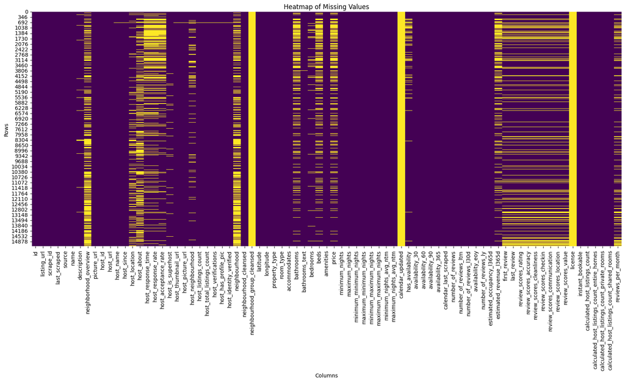

```python
# Visualize missing values with a heatmap
plt.figure(figsize=(20, 8))
sns.heatmap(df.isnull(), cbar=False, cmap='viridis')
plt.title('Heatmap of Missing Values')
plt.xlabel('Columns')
plt.ylabel('Rows')
plt.show()
```

### ✍️ Your Response: 🔧

1. The top 3 columns with the most missing values are license, calendar_updated, and neighborhood_group_cleansed.
2. The columns that are likely to create business issues are missing values that are close to 50%(neighborhood_overview, neighborhood, host_about) . We will probably not remove them completely, but we will likely have to fill in values which might mess with the distribution of these categories.
3. The columns that can be ignored or dropped are the top 3 columns with the most missing data. I made a bar chart looking at the percentages of missing values per category. The categories named license, calendar_updated, and neighborhood_group_cleansed showed that 100% of the data was missing. This woulld make the data not useful for analysis.

## 3. Drop Columns That Aren’t Useful

Business framing:

Not every column adds value. Analysts often remove columns that are too empty, irrelevant, or repetitive — especially when preparing data for others.

Make a decision:

- Choose 2–4 columns to drop from your dataset
- Document your reasons for each one
- Confirm they're gone with `.head()` or `.info()`

### In Your Response:

1. Which columns did you drop?
2. Why were they not useful from a business perspective?
3. What could go wrong if you left them in?

```python
# Add code here 🔧
```

```python
# Drop specific columns
columns_to_drop = ['license', 'calendar_updated', 'neighbourhood_group_cleansed']
df = df.drop(columns=columns_to_drop, errors='ignore') # Use errors='ignore' to avoid error if columns are already dropped

# Verify the columns are dropped
display(df.head())
```

|  | id | listing_url | scrape_id | last_scraped | source | name | description | neighborhood_overview | picture_url | host_id | ... | review_scores_checkin | review_scores_communication | review_scores_location | review_scores_value | instant_bookable | calculated_host_listings_count | calculated_host_listings_count_entire_homes | calculated_host_listings_count_private_rooms | calculated_host_listings_count_shared_rooms | reviews_per_month |
| --- | --- | --- | --- | --- | --- | --- | --- | --- | --- | --- | --- | --- | --- | --- | --- | --- | --- | --- | --- | --- | --- |
| 0 | 5456 | https://www.airbnb.com/rooms/5456 | 20250613040113 | 2025-06-13 | city scrape | Walk to 6th, Rainey St and Convention Ctr | Great central location for walking to Convent... | My neighborhood is ideally located if you want... | https://a0.muscache.com/pictures/14084884/b5a3... | 8028 | ... | 4.90 | 4.82 | 4.73 | 4.79 | f | 1 | 1 | 0 | 0 | 3.59 |
| 1 | 5769 | https://www.airbnb.com/rooms/5769 | 20250613040113 | 2025-06-13 | city scrape | NW Austin Room | NaN | Quiet neighborhood with lots of trees and good... | https://a0.muscache.com/pictures/23822033/ac94... | 8186 | ... | 4.91 | 4.94 | 4.77 | 4.92 | f | 1 | 0 | 1 | 0 | 1.65 |
| 2 | 6413 | https://www.airbnb.com/rooms/6413 | 20250613040113 | 2025-06-14 | previous scrape | Gem of a Studio near Downtown | Great studio apartment, perfect a single perso... | Travis Heights is one of the oldest neighborho... | https://a0.muscache.com/pictures/hosting/Hosti... | 13879 | ... | 4.99 | 4.98 | 4.87 | 4.93 | f | 1 | 1 | 0 | 0 | 0.65 |
| 3 | 6448 | https://www.airbnb.com/rooms/6448 | 20250613040113 | 2025-06-13 | city scrape | Secluded Studio @ Zilker - King Bed, Bright & ... | Clean, private space with everything you need ... | The neighborhood is fun and funky (but quiet)!... | https://a0.muscache.com/pictures/airflow/Hosti... | 14156 | ... | 4.99 | 4.98 | 4.97 | 4.88 | t | 1 | 1 | 0 | 0 | 2.02 |
| 4 | 8502 | https://www.airbnb.com/rooms/8502 | 20250613040113 | 2025-06-13 | city scrape | Woodland Studio Lodging | Studio rental on lower level of home located i... | NaN | https://a0.muscache.com/pictures/miso/Hosting-... | 25298 | ... | 4.85 | 4.88 | 4.69 | 4.63 | f | 1 | 1 | 0 | 0 | 0.29 |

5 rows × 76 columns

### ✍️ Your Response: 🔧

1. I dropped license, calendar_updated, and neighborhood_group_cleansed because they had 100% of missing data in their respective column.
2. From a business perspective, they were not nessicarily useful because they weren't key variables that affected the value of the listing. Additionally the amout of data that we would have to replace would probably show an unaccruate repersentation of the data.
3. If we left the data in, it would possibly contribute to skewed data, outliers, and an overall poor repersentation of the data that was present in these missing columns.

## 4. Fill or Fix Values in Key Columns

Business framing:

Let’s say your manager wants to see a map of listings with prices and review scores. If key fields are blank, the map won’t work. But not all missing values should be filled the same way.

- Choose 2 columns with missing values
- Use a strategy to fill or flag those values
  - (e.g., median, “unknown”, forward-fill, or a placeholder)
- Explain what you did and why

### In your response:

1. What two columns did you clean?
2. What method did you use for each, and why?
3. What risks are there in how you filled the data?

```python
# Your code for converting column data types 🔧
#clean beds and use meadian (numerical)
#clean estimated_revenuel1365D (numerical)
```

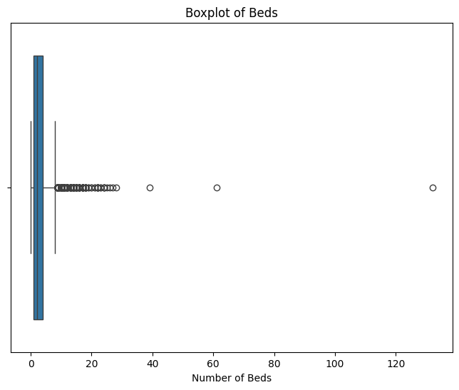

```python
plt.figure(figsize=(8, 6))
sns.boxplot(x=df['beds'])
plt.title('Boxplot of Beds')
plt.xlabel('Number of Beds')
plt.show()
```

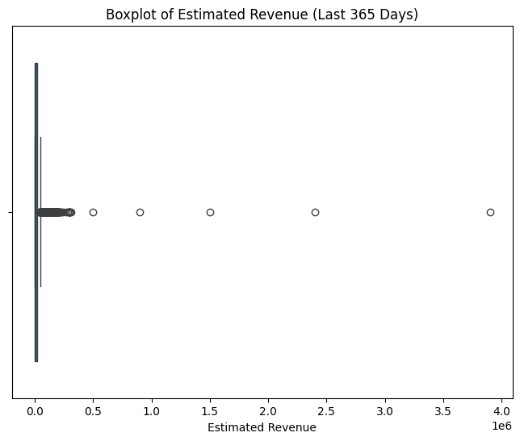

```python
plt.figure(figsize=(8, 6))
sns.boxplot(x=df['estimated_revenue_l365d'])
plt.title('Boxplot of Estimated Revenue (Last 365 Days)')
plt.xlabel('Estimated Revenue')
plt.show()
```

```python
# Calculate the median of the 'beds' column
median_beds = df['estimated_revenue_l365d'].median()

# Fill missing values in the 'beds' column with the median
df['estimated_revenue_l365d'] = df['estimated_revenue_l365d'].fillna(median_beds)

# Verify that there are no more missing values in 'beds'
display(df['estimated_revenue_l365d'].isnull().sum())
```

```
np.int64(0)
```

```python
# Calculate the median of the 'beds' column
median_beds = df['beds'].median()

# Fill missing values in the 'beds' column with the median
df['beds'] = df['beds'].fillna(median_beds)

# Verify that there are no more missing values in 'beds'
display(df['beds'].isnull().sum())
```

```
np.int64(0)
```

### ✍️ Your Response: 🔧

1. I cleaned the beds and the estimated_revenue_l365d( estimated revenue in the last 365 days) columns.
2. For the beds and estimated_revenue_l365d column I filled the values in with the median.These columns are float64 data types which are numerical values. In the Lab 6 guidelines, it said that it was best to fill numerical values with the median when there are outliers.I made a boxplot for both of the columns and they had ouliers, thus it was best to use the median for both columns.
3. There are some risks of filling the data with the median since there was a pretty significant amount of data that was missing from the beds and estimated_revenue_l365d categories( ~30%). Replacing these values could flatten the spread and make the distribution quite different. It could also make things like confidence intervals not as useful because you are essentially replacing unknown data with a best guess.

## 5. Convert and Clean Data Types

Business framing:

Sometimes columns that look like numbers are actually stored as text — which breaks calculations and slows down analysis. Common examples are price columns with dollar signs or availability stored as strings.

- Identify one column with the wrong data type
- Clean and convert it into a usable format (e.g., from string to number)
- Check your work by summarizing or plotting the cleaned column

### In Your Response: :

1. What column did you fix?
2. What cleaning steps did you apply?
3. How does this help prepare the data for later use?

```python
# Clean or adjust your dataset 🔧
```

```python
# Remove '$' and ',' from the 'price' column and convert to float
df['price'] = df['price'].astype(str).str.replace('[$,]', '', regex=True)
df['price'] = pd.to_numeric(df['price'], errors='coerce')

# Verify the data type and display the head
display(df['price'].dtype)
display(df['price'].info())
```

```
dtype('float64')
```

```
<class 'pandas.core.series.Series'>
RangeIndex: 15187 entries, 0 to 15186
Series name: price
Non-Null Count  Dtype
--------------  -----
10708 non-null  float64
dtypes: float64(1)
memory usage: 118.8 KB
```

```
None
```

```python
# Calculate the median of the 'beds' column
median_beds = df['price'].median()

# Fill missing values in the 'beds' column with the median
df['price'] = df['price'].fillna(median_beds)

# Verify that there are no more missing values in 'beds'
display(df['price'].isnull().sum())
```

```
np.int64(0)
```

```python
# Calculate the 1st and 99th percentiles
price_lower_bound = df['price'].quantile(0.01)
price_upper_bound = df['price'].quantile(0.99)

# Clip the price column to these bounds and replace the original 'price' column
df['price'] = df['price'].clip(lower=price_lower_bound, upper=price_upper_bound)

# Display the calculated percentiles and the head of the updated 'price' column
print(f"1st Percentile (Lower Bound): {price_lower_bound}")
print(f"99th Percentile (Upper Bound): {price_upper_bound}")
display(df['price'].head())
display(df['price'].describe())
```

```
1st Percentile (Lower Bound): 31.0
99th Percentile (Upper Bound): 1689.5399999999936
```

|  | price |
| --- | --- |
| 0 | 101.0 |
| 1 | 45.0 |
| 2 | 138.0 |
| 3 | 155.0 |
| 4 | 43.0 |

**dtype:** float64

|  | price |
| --- | --- |
| count | 15187.000000 |
| mean | 198.414241 |
| std | 230.368775 |
| min | 31.000000 |
| 25% | 107.000000 |
| 50% | 138.000000 |
| 75% | 181.000000 |
| max | 1689.540000 |

**dtype:** float64

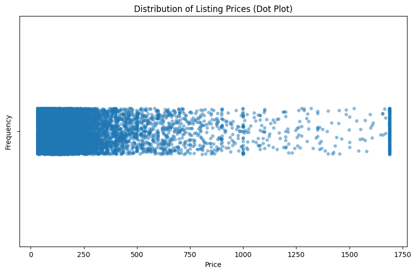

```python
plt.figure(figsize=(10, 6))
sns.stripplot(x=df['price'], jitter=True, alpha=0.5) # Using stripplot for a dot-like representation
plt.title('Distribution of Listing Prices (Dot Plot)')
plt.xlabel('Price')
plt.ylabel('Frequency') # This label is less accurate for a stripplot but kept for context
plt.show()
```

### ✍️ Your Response: 🔧

1. I fixed the price column.
2. The cleaning steps I applied was I changed the data type to be numerical( float64), I filled in the missing values with the median, and I took out ouliers within the 1st and 99th percentiles.
3. Changing the data type makes the price into a more accurate data type, using the median helps make sure that there are no missing values in this category, and taking out extreme outliers helps make the data more uniform.

## 6. Remove Duplicate Records

Business framing:

If a listing appears twice, it could inflate revenue estimates or confuse users. Airbnb needs each listing to be unique and accurate.

- Check for rows that are exact duplicates
- If your data has an ID column and each ID is supposed to unique, then make sure there are no duplicate IDs
- Remove duplicates if found

### In your markdown:

1. Did you find duplicates?
2. How did you decide what to drop or keep?
3. Why are duplicates risky for Airbnb teams?

```python
# Add code here 🔧
```

```python
# Check for duplicate 'id' values
duplicate_ids = df.duplicated(subset=['id'], keep=False)
print(f"Number of rows with duplicate IDs before dropping: {duplicate_ids.sum()}")

# Remove duplicate rows based on 'id', keeping the first occurrence
df_cleaned = df.drop_duplicates(subset=['id'], keep='first')

# Verify that duplicates have been removed
print(f"Number of rows after dropping duplicates: {len(df_cleaned)}")
print(f"Number of duplicate IDs after dropping: {df_cleaned.duplicated(subset=['id'], keep=False).sum()}")

# Update the original dataframe reference if needed, or use df_cleaned for further steps
df = df_cleaned
```

```
Number of rows with duplicate IDs before dropping: 0
Number of rows after dropping duplicates: 15187
Number of duplicate IDs after dropping: 0
```

### ✍️ Your Response: 🔧 🔧

1. There were no duplicates in my dataset.
2. I didn't have to decide what to drop or keep because there were no duplicates.
3. Duplicates are risky for Airbnb teams because ID numbers are unique identifiers for a listing. If there are duplicates it can lead skewed statistics, it can take away from the user experience, it also causes confusion on Airbnb's side and creates overall opperational confusion on their end.

## 7. Export Cleaned Data

Before wrapping up, export your cleaned Airbnb dataset to a CSV file. You'll need this file for **Assignment 7**, where you'll perform data transformation techniques.

Make sure your data has:

- Cleaned and consistent column values
- Proper data types for each column
- Any unnecessary columns removed

This file should be the version of your dataset that you’d feel confident sharing with a teammate or using for deeper analysis.

```
# Explanation:
# - "cleaned_airbnb_data.csv" is the name of the file that will be saved
# - index=False prevents pandas from writing row numbers into the CSV
# - The file will be saved to your working directory (in Colab, you'll need to download it manually. Once you see the data in your files tab, just click on the three dots, then click “download”)
# - YOU MAY NEED TO PRESS “RUN” MULTIPLE TIMES IN ORDER FOR IT TO SHOW UP
# - FOR SOME DEVICES, IT MAY TAKE A FEW MINUTES BEFORE YOUR FILE SHOWS UP
```

```python
# export csv here 🔧
```

```python
# Save the cleaned DataFrame to a CSV file
df.to_csv("cleaned_airbnb_data.csv", index=False)
```

## 8. Final Reflection

You’ve just cleaned a real-world Airbnb dataset — the kind of work that happens every day in analyst and data science roles.

Before you move on to data transformation in Assignment 7, take a few moments to reflect on the decisions you made and what you learned.

### In your markdown:

1. What was the most surprising or challenging part of cleaning this dataset?
2. How did you decide which data to drop, fix, or keep?
3. What’s one way a business team (e.g., hosts, pricing analysts, platform ops) might benefit from the cleaned version of this data?
4. If you had more time, what would you explore or clean further?
5. How does this relate to your customized learning outcome you created in canvas?

Write your response clearly in full sentences. No more than a few sentences required per response.

### ✍️ Your Response: 🔧

1. The most challenging part of cleaning this dataset was being able to decipher what each of the variables were. Additionally, because there was not a specific objective for this data set, it was difficult to determine what variables were key to clean for analysis.
2. I decided to drop the data with the most missing data (100% missing). I decided to fill in 2 of the missing values that were numerical becuase it seemed better to generallize the numerical data rather than the categorical data, which were at times unique customer reviews, or areas around Austin. I chose price to turn into numerical data because the data was expressed as numbers, it just had a dollar sign in front that classified it as an object.
3. One way a business team of price analysts can benifit from the cleaned version of this data set is they can make better data-driven pricing decisions that can in turn increase revenue and competitiveness.
4. If I had more time I would take out or replace all the missing variables from the data. I would also remove all extreme outliers, lastly I would convert categorical data into numerical data when needed.
5. This relates to my customized learning outcome because data cleaning is the foundation that makes both sustainability optimization and problem-solving frameworks possible. Without clean data, my analysis can be misleading or not trustworthy.

## Submission Instructions

✅ Checklist:

- All code cells run without error
- All markdown responses are complete
- Submit on Canvas as instructed

```python
!jupyter nbconvert --to html "assignment_06_LastnameFirstname.ipynb"
```